# Empirical Evaluation of eval in R

# Data

[output not shown]

[output not shown]

```r
nb_unique_calls <- nrow(eval_calls)

r("unique calls", nb_unique_calls)
```

| name | value |
| --- | --- |
| unique calls (\\UniqueCalls) | 862,138 |

There are 862138 unique calls;

The columns of the dataset are the following ones:

```r
column_names %>% knitr::kable()
```

| name | Description |
| --- | --- |
| file | File where the `eval` is executed |
| eval_function | One of `eval`, `evalq`, `eval.parent`, and `local`. |
| eval_call_expression | The full expression with `eval` that has been traced. |
| eval_call_srcref | File name and line where the `eval` call is. Might ne NA, especially for calls originating from package base. |
| caller_package | Package in which the `eval` is called. |
| caller_function | Function in which the `eval` is called. |
| caller_expression | Expression in which the `eval` is called. |
| caller_srcref | File name and line where the caller of the `eval` is located. Might be NA (especially for callers in base). |
| expr_parsed_expression | Contains the expression with a call to `parse` if there is one in the `expr` argument somewhere in the call stack. |
| eval_call_id | Unique id of a call |
| caller_stack_expression | When `eval_function` == `caller_function`, climb up the stack to find the first different caller. |
| caller_stack_expression_raw | See `caller_stack_expression`. Does not use `expr_to_str` but `format`. |
| caller_stack_expression_srcref | srcref for `caller_stack_expression`. |

# Corpus

# Research Questions

## RQ1: How many evals are there?

There are four kinds of `eval` in the `base` package. Their definitions are shown below.

```r
base::eval <-
    function(expr,
             envir = parent.frame(),
             enclos = if (is.list(envir)||is.pairlist(envir)) parent.frame() else baseenv())
        .Internal(eval(expr, envir, enclos))

base::evalq <-
    function (expr,
              envir = parent.frame(),
              enclos = if (is.list(envir) || is.pairlist(envir)) parent.frame() else baseenv())
        .Internal(eval(substitute(expr), envir, enclos))

base::eval.parent <-
    function (expr, n = 1) {
        p <- parent.frame(n + 1)
        eval(expr, p)
    }

base::local <-
    function (expr, envir = new.env())
        eval.parent(substitute(eval(quote(expr), envir)))
```

```r
callsites_with_srcref <-
    eval_calls %>%
    select(eval_call_srcref) %>%
    n_distinct(na.rm = TRUE)

callsites_without_srcref <-
    eval_calls %>%
    filter(is.na(eval_call_srcref)) %>%
    select(caller_package, caller_function) %>%
    n_distinct()

eval_calls <-
    eval_calls %>%
    mutate(eval_call_srcref = coalesce(eval_call_srcref,
                                       str_c("missing", "::", caller_package, "::", caller_function)))
eval_count_table <-
    eval_calls %>%
    group_by(eval_function, eval_call_srcref) %>%
    summarize(count = sum(nb_ev_calls)) %>%
    summarize(call_count = sum(count), callsite_count = n())
nb_eval_calls <- total_call_count <- sum(eval_count_table$call_count)

nb_call_sites <- total_callsite_count <- sum(eval_count_table$callsite_count)

eval_count_table <-
    eval_count_table %>%
    mutate(call_proportion = 100 * call_count / total_call_count,
           callsite_proportion = 100 * callsite_count / total_callsite_count) %>%
    arrange(desc(call_count))

eval_call_proportion <-
    eval_count_table %>%
    filter(eval_function == "eval") %>%
    pull(call_proportion)
```

```r
eval_count_table %>%
select(eval_function, call_count, call_proportion) %>%
datatable()
```

|  | eval_function | call_count | call_proportion |
| --- | --- | --- | --- |
| 1 | eval | 9902594 | 94.3171559873324 |
| 2 | evalq | 222229 | 2.11661785365621 |
| 3 | eval.parent | 198394 | 1.88960163821225 |
| 4 | local | 176033 | 1.6766245207991 |

We observe that 94.317156% of the calls are made to the `eval` function.

These `eval` calls originate from 3729 call sites. For the number of call sites, we use line number information attached to the AST by the parser. When it is not available (such as in *base*), we use a combination of `caller_package` and `caller_function`. We assume that:

- the combination `caller_package` and `caller_function` is unique
- there is only one call site per such `caller_function` This assumption results in a lower bound for the number of unique callsites for eval.

```r
eval_callsite_table <-
    eval_calls %>%
    count(eval_function, caller_package, eval_call_srcref, name = "call_count") %>%
    group_by(eval_function, caller_package) %>%
    summarize(call_count = sum(call_count), callsite_count = n()) %>%
    ungroup()
eval_callsite_table %>%
datatable()
```

|  | eval_function | caller_package | call_count | callsite_count |
| --- | --- | --- | --- | --- |
| 1 | eval | AC_generator | 68 | 1 |
| 2 | eval | AER | 11 | 4 |
| 3 | eval | A_generator | 8 | 1 |
| 4 | eval | AccumulateCallback_generator | 4 | 1 |
| 5 | eval | Adapter_generator | 3 | 1 |
| 6 | eval | AlgDesign | 6 | 1 |
| 7 | eval | AppWrapper_generator | 10 | 1 |
| 8 | eval | AsyncVaried_generator | 2 | 1 |
| 9 | eval | Async_generator | 2 | 1 |
| 10 | eval | BBmisc | 57 | 2 |

[output cut: 452 more lines]

```r
package_callsite_distribution <-
    eval_callsite_table %>%
    mutate(callsite_count = if_else(callsite_count <= 5, as.character(callsite_count), "> 5")) %>%
    group_by(eval_function, callsite_count) %>%
    summarize(package_count = n())
package_callsite_distribution %>%
datatable()
```

|  | eval_function | callsite_count | package_count |
| --- | --- | --- | --- |
| 1 | eval | 1 | 205 |
| 2 | eval | 2 | 42 |
| 3 | eval | 3 | 25 |
| 4 | eval | 4 | 24 |
| 5 | eval | 5 | 17 |
| 6 | eval | &gt; 5 | 89 |
| 7 | eval.parent | 1 | 18 |
| 8 | eval.parent | 2 | 9 |
| 9 | eval.parent | 3 | 6 |
| 10 | eval.parent | 4 | 4 |

[output cut: 9 more lines]

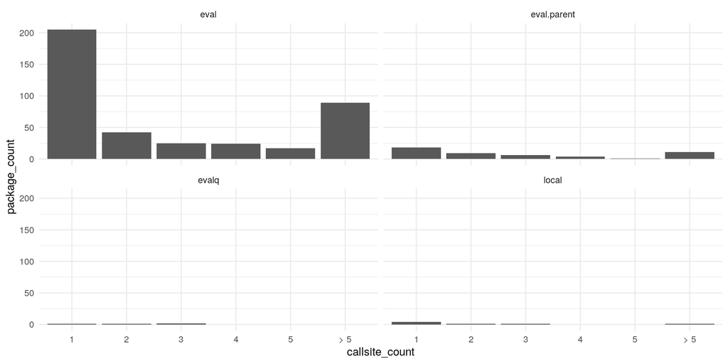

```r
p <-
    package_callsite_distribution %>%
    ggplot(aes(callsite_count, package_count)) +
    geom_col() +
    facet_wrap(vars(eval_function))
p
```

To asses how precise the call site estimate is for calls that do not have `srcref`, we compare it on *base* with the actual count given by `grep`.

```r
nb_call_site_base <- eval_calls %>% filter(caller_package == "base") %>% select(caller_function) %>% n_distinct(na.rm = TRUE)
```

The estimate for *base* is 29 call sites, while `grep` yields 40 `eval` call sites.

For the other packages, ranked by call sites:

```r
eval_calls %>% filter(caller_package != "base") %>% group_by(caller_package) %>% summarize(nb_call_sites =  n_distinct(eval_call_srcref, na.rm = TRUE)) %>% arrange(desc(nb_call_sites))
```

| caller_package | nb_call_sites |
| --- | --- |
| VGAM | 286 |
| metafor | 153 |
| nlme | 119 |
| gamlss | 118 |
| ade4 | 98 |
| stats | 87 |
| survey | 82 |
| lattice | 66 |
| network | 52 |
| actuar | 47 |

[output cut: 398 more lines]

We probably forget the generated ones here, but should we count them in the *call sites*?

What are the packages with the highest number of `eval` calls?

```r
nb_eval_calls_per_package <- eval_calls %>% group_by(caller_package) %>% summarise(nb_eval_calls_package = sum(nb_ev_calls), per_cent = nb_eval_calls_package / nb_eval_calls * 100) %>% arrange(desc(nb_eval_calls_package))
```

*base* has the highest number of eval calls, i.e. 76.0494892% of them.

```r
nb_eval_calls_per_package  %>% datatable()
```

|  | caller_package | nb_eval_calls_package | per_cent |
| --- | --- | --- | --- |
| 1 | base | 7984626 | 76.0494892492321 |
| 2 | ggplot2 | 754761 | 7.18871347953425 |
| 3 | stats | 365139 | 3.47776269733552 |
| 4 | magrittr | 226826 | 2.16040193347144 |
| 5 | utils | 215808 | 2.0554611043646 |
| 6 | methods | 119600 | 1.13912898540372 |
| 7 | glue | 67670 | 0.644522227778175 |
| 8 | data.table | 59383 | 0.565592780436698 |
| 9 | VGAM | 57370 | 0.546419982379694 |
| 10 | Stack_generator | 57046 | 0.543334047670072 |

[output cut: 399 more lines]

### Unknown evals

Some `eval` do not have srcref information attached and are not in *base*. It is often because they are located in a function that is created by anotehr function.

```r
undefined_evals <- eval_calls %>% filter(eval_source_type == "<undefined>")

nb_undefined <- undefined_evals %>% count(wt = nb_ev_calls)

nb_different_call_expr <- undefined_evals %>% select(eval_call_expression) %>% n_distinct()

r("undefined evals", nb_undefined$n)
```

| name | value |
| --- | --- |
| undefined evals (\\UndefinedEvals) | 162,274 |

```r
r("percent undefined eval", ratio(nb_undefined$n, nb_eval_calls))
```

| name | value |
| --- | --- |
| percent undefined eval (\\PercentUndefinedEval) | 1.5% |

```r
r("undefined eval expressions", nb_different_call_expr)
```

| name | value |
| --- | --- |
| undefined eval expressions (\\UndefinedEvalExpressions) | 84 |

### Excluding *base* from the data set

We reckon that `eval` in *base* should be considered apart from the other `eval` calls.

| Function name | File | Line | Parse ? | Comments |
| --- | --- | --- | --- | --- |
| autoload | autoload | 25 |  |  |
| autoloader | autoload | 43 |  | To execute a call to library |
| autoloader | autoload | 49 |  |  |
| bquote | backquote | 33 |  | In subfunction unquote. To eval what is in .() . Metaprogramming |
| bquote | backquote | 56 |  | idem (in unquote.list, defined inside bquote) |
| by.default | by | 35 |  | eval(substitute pattern? |
| by.data.frame | by | 50 |  | idem |
| invokeRestartInteractively | conditions | 245 | yes | prompt |
| invokeRestartInteractively | conditions | 249 | yes | prompt |
| Ops.data.frame | dataframe | 1678 |  | for arithmetic operators on data frames ; do.call could be probably used here also |
| dget | dput | 32 | yes | from file |
| eval | eval | 26 |  | Call Internal eval |
| eval.parent | eval | 30 |  |  |
| evalq | eval | 36 |  | evalq is basically eval(substitute |
| local | eval | 49 |  |  |
| with.default | eval | 57 |  |  |
| within.data.frame | eval | 63 |  |  |
| within.list | eval | 77 |  | evalq |
| replicate | replicate | 21 |  |  |
| subset.data.frame | frametools | 25 |  |  |
| subset.data.frame | frametools | 34 |  |  |
| subset.matrix | frametools | 56 |  |  |
| transform.data.frame | frametools | 69 |  |  |
| match.arg | match | 45 |  |  |
| char.expand | match | 79 |  |  |
| max.col | max | 22 |  | To access formals |
| parseNamespaceFile | namespace | 1315 | yes | To parse directives |
| idem | namespace | 1319 | yes |  |
| idem | namespace | 1442 | yes | evaluate a call from a parse |
| source | source | 123 | yes | Use the internal parse function (here it is a comment) |
| source | source | 170 | yes | comment |
| source | source | 219 | yes | the actual eval |
| sys.source | source | 277 | yes | the non-internal parse is used |
| stopifnot | stop | 54 |  | change of caller pattern |
| as.data.frame.table | table | 244 |  | Build a call? |
| match.fun | match.fun | 28 |  | eval.parent |
| trace | methodsSupport | 38 |  | eval.parent |
| untrace | methodsSupport | 53 |  | eval.parent |
| .doTrace | methodsSupport | 78 |  | eval.parent |

```r
parsed_base <- eval_calls %>% filter(!is.na(expr_parsed_expression), eval_source == "base")

nb_call_site_parse_base <-  nb_eval_call_sites(parsed_base)
```

There are

| n |
| --- |
| 305 |

`eval` calls with `parse` in *base*, which is

| n |
| --- |
| 3.876014e-05 |

%.

## Size of expressions as arguments to `eval`

### String size

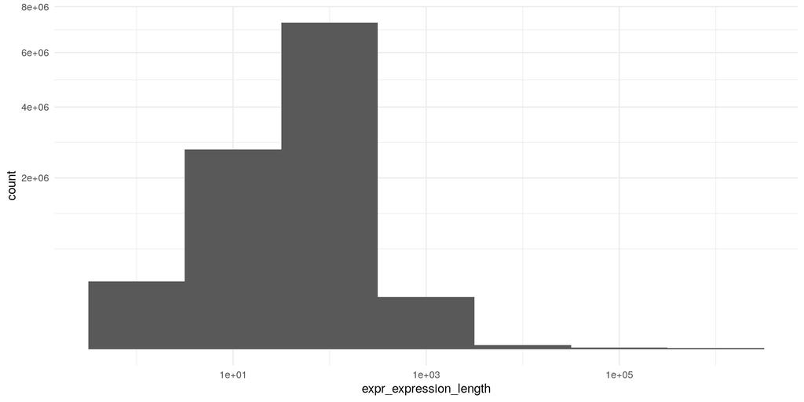

```r
eval_calls %>% ggplot() +
  geom_histogram(aes(x = expr_expression_length, weight = nb_ev_calls), na.rm = TRUE, binwidth=1) +
  scale_x_log10() +  scale_y_sqrt()
```

If we remove the outliers:

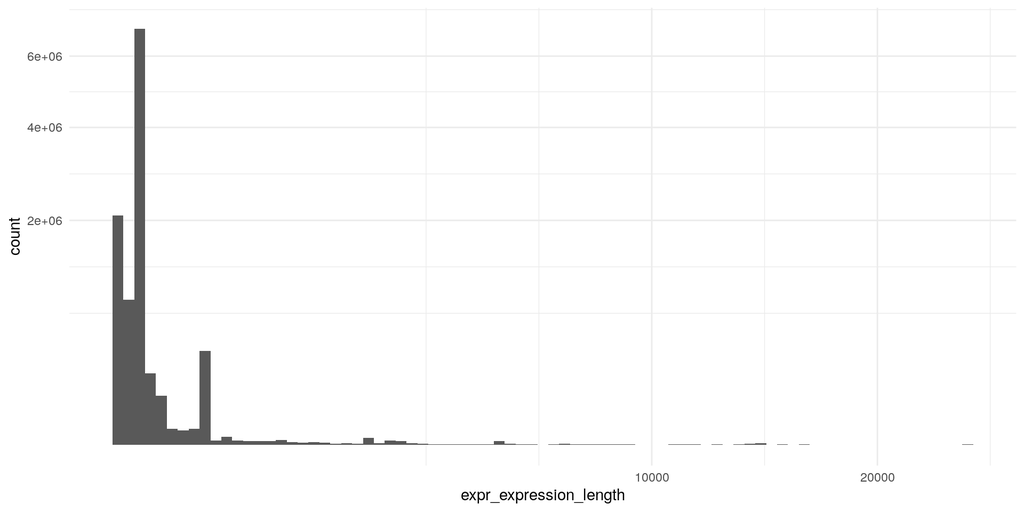

```r
eval_calls %>% filter(expr_expression_length < 25000) %>% ggplot() +
  geom_histogram(aes(x = expr_expression_length, weight = nb_ev_calls), na.rm = TRUE, binwidth=2)  + scale_x_sqrt() +  scale_y_sqrt()
```

What about the code size of expressions that seem to be generated? An approximation of *generated* will be no `srcref` and not in `base`.

[figure not shown]

```r
eval_calls %>% filter(is.na(eval_call_srcref), caller_package != "base") %>% ggplot() +
  geom_histogram(aes(x = expr_expression_length, weight = nb_ev_calls), na.rm = TRUE, binwidth=1) + scale_x_sqrt() + scale_y_sqrt()
```

And the average size per package:

```r
eval_calls %>% group_by(caller_package) %>% summarize(average_expr_size = mean(expr_expression_length, na.rm = TRUE)) %>% arrange(desc(average_expr_size))
```

| caller_package | average_expr_size |
| --- | --- |
| doRNG | 559.500000 |
| memoise | 513.160000 |
| estimatr | 505.500000 |
| VGAM | 302.139906 |
| utf8 | 280.000000 |
| base | 227.409496 |
| Rcpp | 183.571795 |
| rprojroot | 164.814815 |
| ROCR | 159.000000 |
| future | 112.444444 |

[output cut: 399 more lines]

If we look at the maxima, the largest ones are in *base*:

```r
eval_calls %>% group_by(caller_package) %>% summarize(max_expr_size = max(expr_expression_length, na.rm = TRUE)) %>% arrange(desc(max_expr_size))
```

| caller_package | max_expr_size |
| --- | --- |
| base | 1220792 |
| VGAM | 8834 |
| future | 2705 |
| memoise | 768 |
| doRNG | 718 |
| estimatr | 509 |
| lfe | 339 |
| utf8 | 280 |
| glm2 | 264 |
| stats | 264 |

[output cut: 399 more lines]

### AST size

```r
ast_sizes <- eval_calls %>% slice_sample(n=10000) %>% mutate(expr_resolved_ast_size = map_int(expr_resolved, expr_size_str))
```

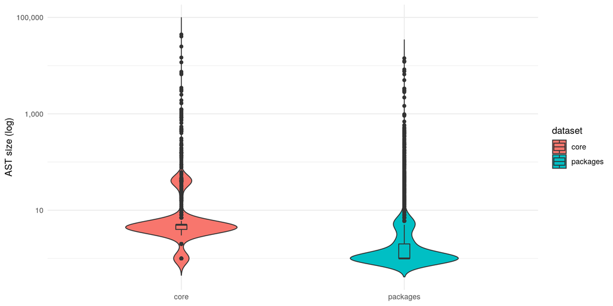

```r
# ast_sizes %>% ggplot(aes(x = expr_resolved_ast_size, weight = nb_ev_calls, group = dataset)) +
#   geom_histogram(aes(y = stat(width*density)), na.rm = TRUE, binwidth = 0.1) +
#   scale_x_log10() +  scale_y_sqrt(labels=scales::percent) +
#   labs(x = "AST size", y = "relative frequencies")

# ast_sizes %>%
#   ggplot(aes(x = dataset, y = expr_resolved_ast_size, fill = dataset, weight = nb_ev_calls)) +
#   geom_flat_violin(trim=FALSE, width=.5) +
#   geom_dotplot(
#     binaxis="y",
#     dotsize=0.01,
#     stackdir="down",
#     binwidth=0.01,
#     position=position_nudge(-0.025)) +
#   scale_y_log10(labels = scales::comma) +
#   labs(y="AST size (log)") +
#   theme(
#     legend.box="horizontal",
#     axis.title.x=element_blank()
#   )

ast_sizes %>%
  ggplot(aes(x = dataset, y = expr_resolved_ast_size, fill = dataset, weight = nb_ev_calls)) +
  geom_violin(trim = FALSE, width=.5)+
  geom_boxplot(width=.05) +
  scale_y_log10(labels = scales::comma) +
  labs(y="AST size (log)") +
  theme(
    legend.box="horizontal",
    axis.title.x=element_blank()
  )
```

```r
ggsave(path(PLOT_DIR, "ast_sizes.pdf"))
```

## Amount of computations performed in `eval`

## Aliases of `eval`

# A taxonomy of `eval`

## The operation mix

## Scope (environments)

```r
default_envir <- eval_calls %>% filter(is.na(envir_expression))
nb_default_envir <- default_envir %>% count(wt = nb_ev_calls)
nb_call_sites_default_envir <- nb_eval_call_sites(default_envir)
```

We also classify environments in the following way:

- `base`: environment of a primitive function of *base* package
- `empty`: empty environment
- `callee`: same environment (it seems it only happens with `local` )
- `global`: `.GlobalEnv`
- `package:package_name`: package environment
- `loop`: there was a loop in the frame

```r
# classified_envir <- eval_calls %>% filter(!is.na(envir_expression)) %>%
#       mutate(env_class = pmap(list(environment_class, envir_type, envir_expression), extract_envir)) %>%
#       unnest_wider(env_class)

#TODO
```

## Patterns

We look at the first argument of `eval`, the `expr` argument, after it is resolved. It is the expression to be evaluated. It can be of different types, mainly usual numeric types, vectors, strings, and language types: calls, symbols, promise, bytecode and expressions.

`bytecode` refers to bytecode objects, that are generated by the `compile`function:

```r
typeof(compiler::compile(1+1))
```

```
## [1] "bytecode"
```

Type `expression` is a sequence of calls and symbols.

```r
per_expr_resolved_type <- eval_calls %>% count(expr_resolved_type, wt = nb_ev_calls)
```

```r
 per_expr_resolved_type %>% mutate(per_cent = n / nb_eval_calls * 100 ) %>% arrange(desc(n)) %>% knitr::kable()
```

| expr_resolved_type | n | per_cent |
| --- | --- | --- |
| LANGSXP | 8407307 | 80.0753101 |
| ENVSXP | 756237 | 7.2027716 |
| NA | 401778 | 3.8267305 |
| EXPRSXP | 365535 | 3.4815344 |
| NILSXP | 231161 | 2.2016906 |
| INTSXP | 82150 | 0.7824368 |
| LGLSXP | 71246 | 0.6785818 |
| STRSXP | 66829 | 0.6365121 |
| REALSXP | 30619 | 0.2916304 |
| VECSXP | 28591 | 0.2723147 |
| SYMSXP | 24235 | 0.2308260 |
| CLOSXP | 19690 | 0.1875372 |
| BCODESXP | 13350 | 0.1271519 |
| S4SXP | 460 | 0.0043813 |
| BUILTINSXP | 35 | 0.0003334 |
| EXTPTRSXP | 21 | 0.0002000 |
| SPECIALSXP | 6 | 0.0000571 |

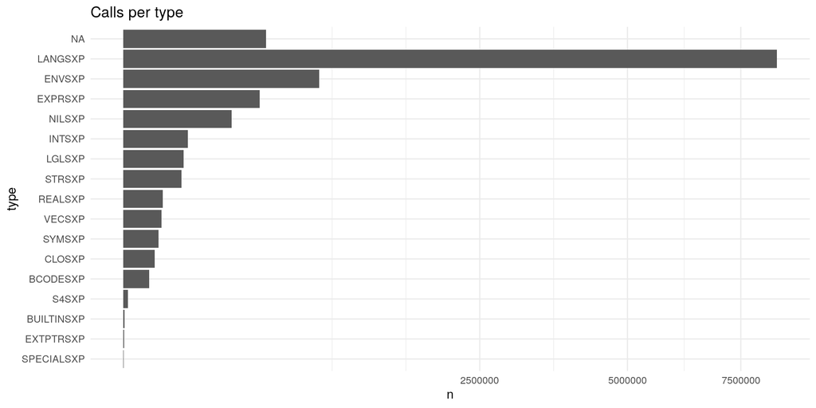

```r
per_expr_resolved_type %>% ggplot() +
  geom_col(aes(x = fct_reorder(expr_resolved_type, n), y = n)) +
  scale_y_sqrt() +
  coord_flip() +
  labs(title = "Calls per type", y = "n", x = "type" )
```

There is a much larger variety of types for the resolved expressions.

```r
changed_resolved_evals <- eval_calls %>% mutate(changed =  fct_collapse(expr_resolved_type, lang_types = c("LANGSXP", "EXPRSXP", "SYMSXP", "PROMSXP", "BCODESXP"), other_level = "other_types")) %>% count(changed, wt = nb_eval_calls) %>% mutate(per_cent = n / nb_eval_calls * 100 )
```

```r
expr_resolved_call_arg <- eval_calls %>% filter(expr_resolved_type == "LANGSXP")
```

The following top level functions are used:

```r
expr_resolved_call_arg %>% count(expr_resolved_function, wt=nb_ev_calls) %>% arrange(desc(n))
```

| expr_resolved_function | n |
| --- | --- |
| c | 6471695 |
| eval | 366003 |
| { | 331988 |
| list | 170280 |
| function | 155769 |
| FUN | 110350 |
| missing | 66138 |
| stats::model.frame | 53797 |
| _fseq | 47290 |
| substitute | 44447 |

[output cut: 1455 more lines]

We can distinguish a few groups:

- assignments
- reading (in a data frame, a vector)
- parsing
- defusing (`quote`, `substitute` and so on)
- conversion or creation of new values
- building calls and calling
- working with environments
- class assignments, reads and definitions
- building logical values
- formula
- meta programming on functions (getting access to the body of the function, to the call stack)
- ‘NA’ corresponds to no function calls (or that it was not parsed successfully)
- anonymous functions

```r
group_expr_resolved_functions <- expr_resolved_call_arg %>%
                            mutate(function_expr2 = groupify_function(expr_resolved_function)) %>%
                            mutate(group_function_expr = fct_collapse(function_expr2,
                              assignment = c("<-", "[[<-", "[<-", "$<-", "<<-", "=", "@<-"),
                              slot_access = c("[", "[[", "$", "slot", "@", "::", ":::"),
                              parsing = c("parse", "str2lang", "str2expression", "parse_only", "base::parse"),
                              defusing = c("quote", "substitute", "bquote", "expr", "quo"),
                              expressions = c("as.list", "expression", "as.name", "as.expression", "list", "c", "as.data.frame", "as.character", "{", "modify_lang"),
                              calling = c("call", "as.call", "do.call"),
                              environment = c("environment", "as.environment"),
                              logical = c("!", "&", "|", "&&", "||"),
                              relation = c("<", ">", "is.element", "<=", "=>", "!="),
                              choice = c("if"),
                              anonymous = c("anonymous"),
                              primitive = c("primitive"),
                              function_meta = c("sys.calls", "function", "body", "missing"),
                              arithmetic = c("+", "-", "*", "/", "%%", "^"),
                              formula = c("~", "deriv", "D", "model.frame", "rootftfunc", "contest.lmerModLmerTest", "JacFunc", "gamlss.family", "contest1D.lmerModLmerTest", "contestMD.lmerModLmerTest", "reexpr"),
                              other_level = "other" ))
group_expr_resolved_functions %>% count(group_function_expr, wt = nb_ev_calls) %>% arrange(desc(n)) %>% knitr::kable()
```

| group_function_expr | n |
| --- | --- |
| expressions | 6977103 |
| other | 877771 |
| function_meta | 222130 |
| assignment | 84258 |
| slot_access | 64077 |
| arithmetic | 63833 |
| formula | 51612 |
| defusing | 44456 |
| logical | 20008 |
| relation | 1815 |
| calling | 98 |
| choice | 66 |
| environment | 51 |
| parsing | 29 |

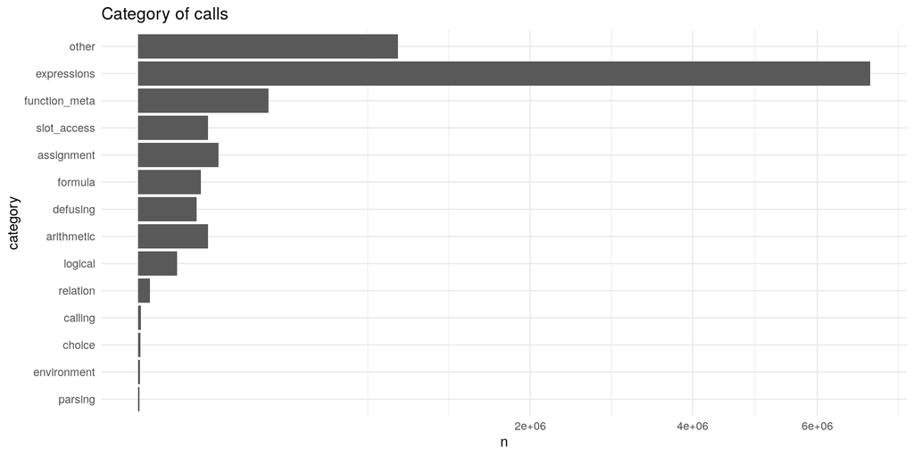

```r
group_expr_resolved_functions %>% ggplot() +
  geom_bar(aes(x = fct_rev(fct_infreq(group_function_expr)), weight = nb_ev_calls)) +
  scale_y_sqrt() +
  coord_flip() +
  labs(title = "Category of calls", y = "n", x = "category" )
```

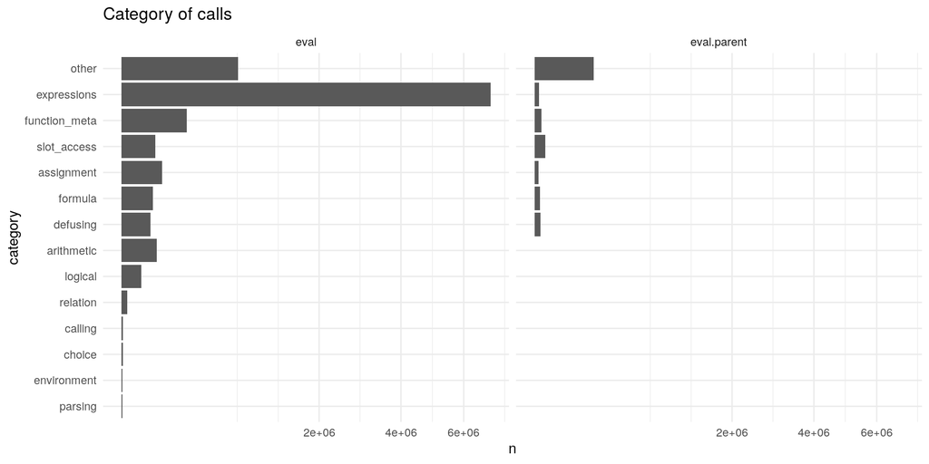

```r
group_expr_resolved_functions %>% ggplot() +
  geom_bar(aes(x = fct_rev(fct_infreq(group_function_expr)), weight = nb_ev_calls)) +
  scale_y_sqrt() +
  coord_flip() +
  labs(title = "Category of calls", y = "n", x = "category" ) +
  facet_wrap(vars(eval_function))
```

We also look at the arity of the top-level function:

```r
expr_resolved_call_arg %>% count(expr_expression_args_num, sort = TRUE) %>% knitr::kable()
```

| expr_expression_args_num | n |
| --- | --- |
| 1 | 237290 |
| 2 | 115561 |
| NA | 113268 |
| 3 | 19705 |
| 12 | 7441 |
| 8 | 62 |
| 5 | 51 |
| 0 | 9 |
| 4 | 9 |

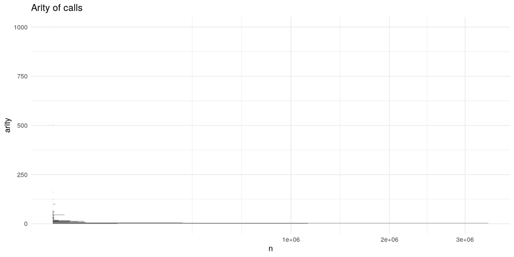

```r
expr_resolved_call_arg %>% ggplot() +
  geom_bar(aes(x = expr_resolved_args_num, weight = nb_ev_calls)) +
  scale_y_sqrt() +
  coord_flip() +
  labs(title = "Arity of calls", x = "arity", y = "n")
```

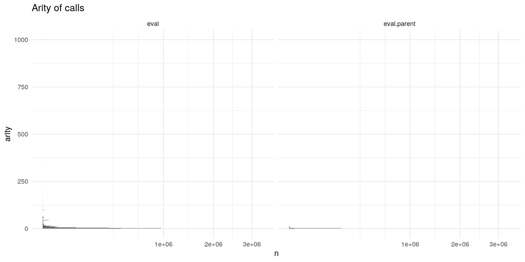

```r
expr_resolved_call_arg %>% ggplot() +
  geom_bar(aes(x = expr_resolved_args_num, weight = nb_ev_calls)) +
  scale_y_sqrt() +
  coord_flip() +
  labs(title = "Arity of calls", x = "arity", y = "n") +
  facet_wrap(vars(eval_function))
```

Another interesting figure is the degreee of polymorphism of the `expr` argument: how many different types (for `expr_resolved`) are there for one call sites?

```r
expr_resolved_polymorphism <- eval_calls %>% group_by(eval_call_srcref) %>%
        summarise(polym_degree = vec_unique_count(expr_resolved_type))
expr_resolved_monomorphic <- expr_resolved_polymorphism %>% filter(polym_degree == 1)
nb_monomorphic <- expr_resolved_monomorphic %>% nrow()

r("nb monomorphic", nb_monomorphic)
```

| name | value |
| --- | --- |
| nb monomorphic (\\NbMonomorphic) | 3,427 |

```r
r("percent monomorphic", ratio(nb_monomorphic, nb_call_sites))
```

| name | value |
| --- | --- |
| percent monomorphic (\\PercentMonomorphic) | 91.9% |

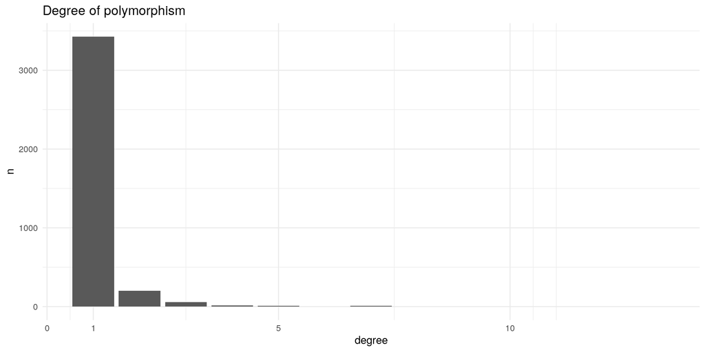

```r
expr_resolved_polymorphism %>% ggplot() +
  geom_bar(aes(x = polym_degree)) +
  scale_x_continuous(breaks=c(0, 1, 5, 10)) +
  labs(title = "Degree of polymorphism", x = "degree", y = "n")
```

```r
ggsave(path(PLOT_DIR, "polymorphism.pdf"))
```

3427 call sites are not polymorphic, which represents 91.901314% of the call sites.

```r
expr_resolved_replaceable <- expr_resolved_monomorphic %>% left_join(eval_calls) %>% mutate(can_replace = map_lgl(expr_resolved,  is_replaceable_str))
```

## Provenance

Some `eval` result from parsing text (directly or through a file) with `parse`.

```r
parsed_evals <- eval_calls %>% filter(!is.na(expr_parsed_expression))
nb_parsed_evals <- parsed_evals %>% count(wt = nb_ev_calls)

r("percent parsed evals",  ratio(nb_parsed_evals$n, nb_eval_calls))
```

| name | value |
| --- | --- |
| percent parsed evals (\\PercentParsedEvals) | 1.2% |

There are

| n |
| --- |
| 123006 |

such calls,

| n |
| --- |
| 1.171569 |

%.

| name | value |
| --- | --- |
| percent parsed call sites (\\PercentParsedCallSites) | 9.1% |

In terms of call sites, there are 339 i.e. 9.0909091%.

We can differentiate further the provenance, i.e. whether the evaluated string comes from `file` or from `text`.

```r
if("parse_args_file" %in% names(parsed_evals))
{
  parsed_files <- parsed_evals %>% filter(!is.na(parse_args_file))
  nb_file <- parsed_files %>% count(wt = nb_ev_calls)
  nb_file_call_sites <- nb_eval_call_sites(parsed_files)
} else
{
  nb_file <- 0
  nb_file_call_sites <- 0
}
```

```r
parsed_texts <- parsed_evals %>% filter(!is.na(parse_args_text) | !is.na(parse_args_s))
nb_text <-  parsed_texts %>% count(wt = nb_ev_calls)
nb_text_call_sites <- nb_eval_call_sites(parsed_texts)
```

There are 0 calls with the `file` argument, and

| n |
| --- |
| 121857 |

with the `text` argument, i.e.

| n |
| --- |
| 0 |

%, and

| n |
| --- |
| 99.0659 |

% respectively.

There are 0 call sites with the `file` argument, and 329 with the `text` argument, i.e. 0%, and 97.0501475% respectively.

We also look to the occurrences of `paste` (and `parse0`), `glue` and `str_c` in the `parse` argument. It is an indication that meta-pogramming happens.

```r
meta_parsed <- parsed_texts %>% filter(str_detect(expr_parsed_expression, "paste|str_c|glue"))

nb_meta_parsed <- meta_parsed %>% count(wt = nb_ev_calls)
nb_meta_parsed_call_sites <- nb_eval_call_sites(meta_parsed)

r("paste parsed evals", ratio(nb_meta_parsed$n,  nb_parsed_evals$n))
```

| name | value |
| --- | --- |
| paste parsed evals (\\PasteParsedEvals) | 52.3% |

```r
r("paste parsed call site", ratio(nb_meta_parsed_call_sites,  nb_parsed_call_sites))
```

| name | value |
| --- | --- |
| paste parsed call site (\\PasteParsedCallSite) | 38.1% |

We can look at the most common meta-programming examples:

```r
meta_parsed %>% count(expr_parsed_expression, wt = nb_ev_calls, sort = TRUE)
```

| expr_parsed_expression | n |
| --- | --- |
| str2lang(paste0("target@", s, " <- source@", s)) | 23918 |
| parse(text = paste0("options(", i, "=", opts[i], ")")) | 17625 |
| parse(text = paste("~", paste(names(val), collapse = sep))) | 5834 |
| parse(text = EnvStats::Distribution.df[idist, paste("Parameter", i, "Max", sep = ".")]) | 2165 |
| parse(text = EnvStats::Distribution.df[idist, paste("Parameter", i, "Min", sep = ".")]) | 2165 |
| parse(text = paste("function(x) {", "m <- (", y2, "-", y1, ") / (", x2, "-", x1, ");", "c <- ", y1, " - m * ", x1, ";", "return( m * x + c)}", \n sep = " ")) | 1079 |
| parse(text = paste(chars[str_start:str_end], collapse = "")) | 782 |
| parse(text = (paste(what, ".smoothers", sep = ""))) | 452 |
| parse(text = paste(contrasts[fn[i]], "(", length(levels(hilf[, fn[i]])), ")", sep = "")) | 381 |
| parse(text = (paste("family$", what, ".dr", sep = ""))) | 353 |

[output cut: 105 more lines]

## Consistence

# Other faces of `eval`

# Case studies